# noaa

The goal of the **noaa** package is to provide tools to clean and visualize earthquake data obtained from U.S. National Oceanographic and Atmospheric Administration (NOAA). The package works best with **dplyr**, **ggplot2** and **leaflet**.

```r
library(noaa)
library(dplyr)
```

# Example data

The **noaa** package comes with an example dataset *“noaa_earthquakes.tsv”* obtained from U.S. National Oceanographic and Atmospheric Administration (NOAA)[^1].  
The dataset can be accessed via

```r
path <- system.file("extdata", "noaa_earthquakes.tsv", package = "noaa")
```

# Reading and cleaning data

### Read data with `eq_read_data()`

This function is used to read noaa data that follows the data structure fo U.S. National Oceanographic and Atmospheric Administration. The function expects one input argument:

- `path`: file path

The function returns a dataframe as *tibble*.

```r
noaa_data <- system.file("extdata", "noaa_earthquakes.tsv", package = "noaa") %>%
  eq_read_data()
```

### Clean data with `eq_clean_data()`

`eq_clean_data()` creates a *date* column and converts *longitude* and *latitude* to numeric values. Optionally, `eq_clean_data()` can reformat the column names or call the subroutine `eq_location_clean()` to reformat the *location* column and extract the country name into a new column. Reformating the column names is handled by the internal function `clean_headers()` which is not exported to the **noaa** namespace. `clean_headers()` transforms all column names to uppercase, replaces spaces with "_" and creates the column *EQ_PRIMARY* containing the Richterscale magnitude, if not already present in the dataset.

`eq_clean_data()` expects the following arguments:

- `data`: raw noaa data read with `eq_read_data()`
- `do_clean_location` (*logical*): if true (default), `eq_location_clean()` is executed
- `do_clean_headers` (*logical*): if true (default), column names are reformated

```r
noaa_clean <- noaa_data %>%
  eq_clean_data(do_clean_location = TRUE, do_clean_headers = TRUE)
```

### Clean location column with `eq_location_clean()`

Similar to `eq_clean_data()`, `eq_location_clean()` is used as preprocessing to clean the raw noaa data. The function exctracts the country name from the *loaction* column into the *country* column and replaces US states with “USA”. `eq_location_clean()` is a quoting function, hence its inputs are quoted to be evaluated in the context of the data - similarly to **ggplot2** or **dplyr**. The function expects the following arguments:

- `data`: raw noaa data read with `eq_read_data()`
- `col`: column containing the location information (default: `Location Name`)
- `country`: column name for country information (default: COUNTRY)

```r
noaa_clean <- noaa_data %>%
  eq_location_clean(col = `Location Name`, country = COUNTRY)

noaa_clean <- noaa_data %>%
  eq_location_clean() %>%
  eq_clean_data(do_clean_location = FALSE)
```

# Timeline plotting

### Plot timeline with `plot_eq_timeline()`

`plot_eq_timeline()` is a handy wrapper for `ggplot()`, `geom_timeline()` and `geom_timeline_label()` to plot a timeline of earthquakes grouped by *country* with indicating magnitude and total deaths. The top 5 earthquakes with largest magnitude for each group are labeled. The function expects the following arguments:

- `data`: noaa data cleaned with `eq_clean_data()` where both `do_clean_location = TRUE` and `do_clean_headers = TRUE`
- `label`: column containing the desired label information (default: `LOCATION_NAME`). If `NULL` no labels are drawn.

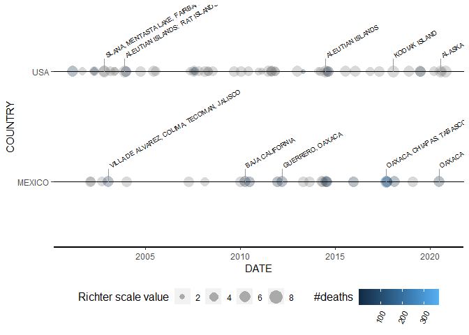

```r
noaa_data %>%
  eq_clean_data() %>%
  filter(COUNTRY %in% c("USA", "MEXICO") & YEAR > 2000) %>%
  plot_eq_timeline()
```

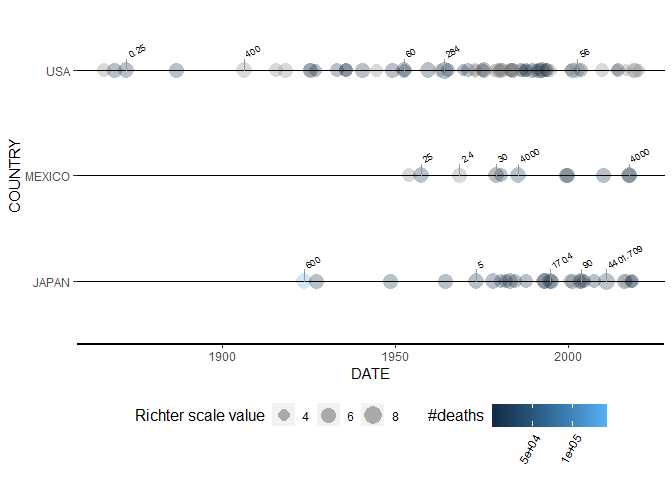

```r
noaa_clean %>%
  filter(COUNTRY %in% c("USA", "MEXICO", "JAPAN") & YEAR > 1000) %>%
  filter(!is.na(`DAMAGE_($MIL)`)) %>%
  plot_eq_timeline(label = `DAMAGE_($MIL)`)
```

### `geom_timeline()`

The timeline geom is used to create earthquake timelines with **ggplot2**. `geom_timeline()` intends to split timelines by some factor variable (e.g. *COUNTRY*) and plot incidents for each point in time per group. Usually, the color scale is mapped to *TOTAL_DEATHS* while shape size is mapped to *MAG* (or *EQ_PRIMARY*). The function’s mapping parameter uses the following aesthetics:

- `x`: required to be *DATE*
- `y`: (optional) grouping variable used to split the timelines (e.g. *COUNTRY*)
- `colour`: (optional) Colour of earthquake marker (e.g. *TOTAL_DEATHS*)
- `size`: (optional) Size of earthquake marker (e.g. *MAG* or *EQ_PRIMARY*)

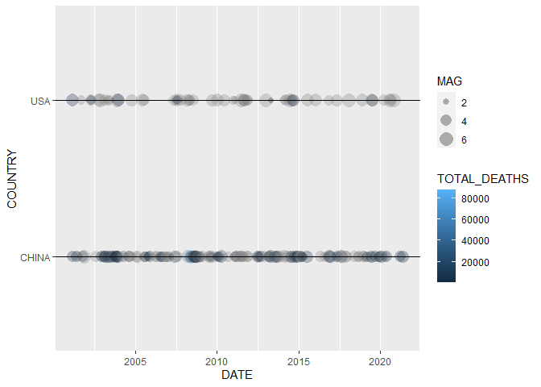

```r
library(ggplot2)

noaa_clean %>%
  filter(COUNTRY %in% c("USA", "CHINA") & YEAR > 2000) %>%
  ggplot(aes(x = DATE, y = COUNTRY, color = TOTAL_DEATHS, size = MAG)) +
  geom_timeline()
```

### `geom_timeline_label()`

`geom_timeline_label()` is used to add labels to the timeline geom (`geom_timeline()`) where only `n_max` (default: 5) incidents regarding Richterscale magnitude are labeled. The function’s mapping parameter uses the following aesthetics:

- `y`: grouping variable by which timelines are split (usually *COUNTRY*)
- `label`: label text (e.g. *LOCATION_NAME*)

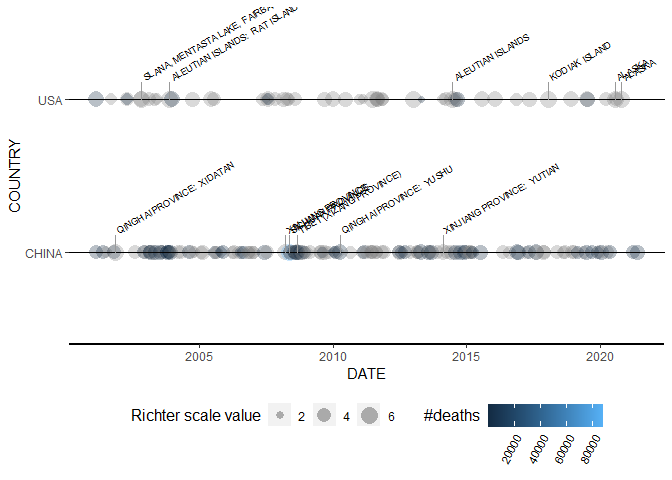

```r
noaa_filtered <- noaa_clean %>%
  filter(COUNTRY %in% c("USA", "CHINA") & YEAR > 2000)

noaa_filtered %>%
  plot_eq_timeline(label = NULL) +
  geom_timeline_label(data = noaa_filtered, mapping = aes(y = COUNTRY, label = LOCATION_NAME), n_max = 6)
```

# Maps and geographic plotting

### Draw a **leaflet** map with `eq_map()`

`eq_map()` creates a leaflet map and draws earthquake incidents using the geographic information of the noaa dataset. The function expects the following arguments:

- `data`: noaa data cleaned with `eq_clean_data()` where both `do_clean_location = TRUE` and `do_clean_headers = TRUE`
- `annot_col`: column to be used as label for popup information

```r
noaa_clean %>%
  filter(COUNTRY %in% c("CANADA", "MEXICO") & YEAR > 2000) %>%
  filter(!is.na(LATITUDE) & !is.na(LONGITUDE)) %>%
  eq_map(annot_col = "DATE")
```

[interactive chart not shown]

### Create popup info text with `eq_create_label()`

`eq_create_label()` is used to combine the information *LOCATION*, *MAGNITUDE* (*EQ_PRIMARY*) and *TOTAL_DEATHS* into a HTML string that can be used as popup text of `eq_map()`. The function receives one input argument:

- `data`: noaa data cleaned with `eq_clean_data()` where both `do_clean_location = TRUE` and `do_clean_headers = TRUE`

```r
noaa_clean %>%
  filter(LONGITUDE > 65 & LONGITUDE < 90 & YEAR > 2000) %>%
  filter(!is.na(LATITUDE) & !is.na(LONGITUDE)) %>%
  mutate(label_text = eq_create_label(.)) %>%
  eq_map(annot_col = "label_text")
```

[interactive chart not shown]

[^1]: National Geophysical Data Center / World Data Service (NGDC/WDS): NCEI/WDS Global Significant Earthquake Database. NOAA National Centers for Environmental Information. [doi:10.7289/V5TD9V7K](https://www.ncei.noaa.gov/access/metadata/landing-page/bin/iso?id=gov.noaa.ngdc.mgg.hazards:G012153)